# Primer Parcial (30pts). Solución

Programacion Estadística I

Lic. Alvaro Chirino Gutierrez

10/6/2020

## Pregunta 1 (5pts).

- (1pt) ¿Qué libreria en R permite definir el diseño muestral de una encuesta por muestreo?

**Resp.** Libreria survey

- (1pt) ¿Qué diferencia existe entre un dataframe y una matriz en R?

**Resp.** Una matriz es un objeto homogeneo mientras que un dataframe es uno heterogeneo

- (2pt) Se realizó una prueba de independencia chi-cuadrado entre el sexo y el partido pólitico de interés en EEUU. El resultado del comando chisq.test en R es el siguiente:

```
##
##  Pearson's Chi-squared test
##
## data:  M
## X-squared = 30.07, df = 2, p-value = 2.954e-07
```

¿Qué puede concluir acerca de la independencia o no del sexo y el partido politico?, justifique su respuesta.

**Resp.** Dado el valor del p-valor se rechaza la hipotesis nula de independencia, podemos concluir que el sexo y el partido político no son independientes.

- (1pt) Mencione en forma resumida los pasos para la recopilación de información en el scraping web.

**Resp.** Los pasos se resumen en:

1. Identificar la información que se necesita
2. Averiguar si existe esa información en la web
3. Evalue la calidad de la información
4. Identificar ventajas y desventajas de realizar la recolección mediante scraping
5. Decidir la fuente más adecuada, pueden ser uno o más

## Pregunta 2 (5 pts)

Escribir el código en R para los siguientes casos:

- (1pt) $\sum_{i=10}^{40}{\left(\frac{2^i}{i}+\frac{3^i}{i^2} \right)}$

**Resp.**

```r
i<-10:40
sum((2^i)/i+(3^i)/(i^2))
```

```
## [1] 1.17064e+16
```

- (1pt) Crear una matriz de $4*5$ que contengan valores aleatorios de una uniforme con $a=0, b=10$

**Resp.**

```r
matrix(runif(20,0,10),nrow=4)
```

```
##          [,1]     [,2]     [,3]      [,4]     [,5]
## [1,] 3.758155 0.696652 9.878924 6.6668256 8.274370
## [2,] 8.684270 8.195497 2.508781 0.6473516 2.725618
## [3,] 5.557982 5.933987 3.590809 2.6304697 8.660015
## [4,] 4.071669 4.251010 7.319937 6.5384973 4.173829
```

- (1pt) Calcular $\sum_{i=1}^{20}{\sum_{j=2}^5{\frac{i^3}{2+ij}}}$

**Resp.**

```r
s<-0
for(i in 1:20){
  for(j in 2:5){
    s<-s+(i^3)/(2+i*j)
  }
}
s
```

```
## [1] 3501.563
```

- (2pts) Crear una función que dado un vector numérico devuelva el coeficiente de variación y el coeficiente de asimetría de Pearson y Fisher.

**Resp.**

```r
fx<-function(x){
  n<-length(x)
  cv<-sd(x)/mean(x)
  #pearson
  p<-(3*(mean(x)-median(x)))/sd(x)
  #fisher
  f<-(sum((x-mean(x))^3)/(n-1))/sd(x)^3
  return(c(cv,p,f))
}
x<-rnorm(1000)
fx(x)
```

```
## [1] -57.64582913  -0.01173740  -0.01514613
```

## Pregunta 3 (10 pts)

Usando la información de www.worldometers.com sobre el COVID con la libreria rvest, generar en un documento R markdown.

- Una tabla que muestre los 10 países con más altos contagios por millón

**Resp.**

```r
library(rvest)
covid<-read_html("https://www.worldometers.info/coronavirus/")
aux<-html_table(covid)
t<-aux[[1]]
names(t)[1]<-"id"
t<-t[!is.na(t$id),]
names(t)[11]<-"casoM"
names(t)[14]<-"testM"
t$casoM<-as.numeric(gsub(",","",t$casoM))
t$testM<-as.numeric(gsub(",","",t$testM))
tt<-t[order(t$casoM,decreasing = T),c(2,11)][1:10,]
knitr::kable(tt,caption = "Top 10 casos por Millon por país")
```

Top 10 casos por Millon por país

|  | Country,Other | casoM |
| --- | --- | --- |
| 27 | Qatar | 26737 |
| 140 | San Marino | 20367 |
| 211 | Vatican City | 14981 |
| 134 | Andorra | 11028 |
| 56 | Bahrain | 9818 |
| 101 | Mayotte | 8223 |
| 40 | Kuwait | 8069 |
| 21 | Chile | 8065 |
| 37 | Singapore | 6735 |
| 16 | Peru | 6519 |

- Un gráfico de los casos por millón ($X$) versus los test por millón ($Y$), incluir en el gráfico los nombres de los países.

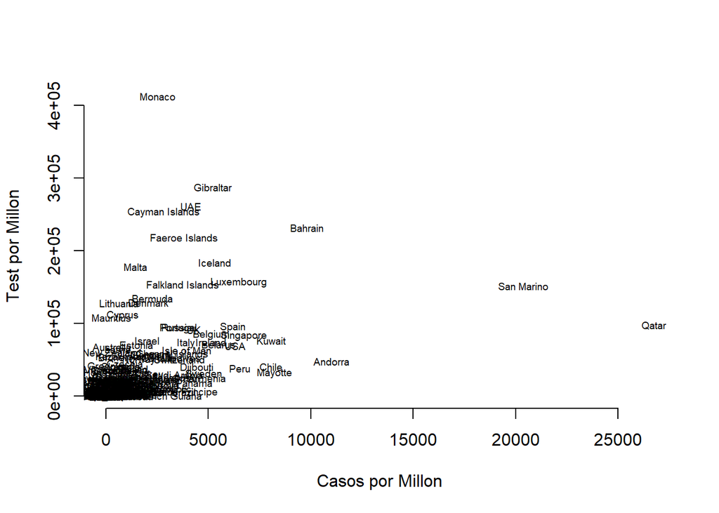

```r
plot(t$casoM,t$testM,type="n",axes=F,ann=F)
text(t$casoM,t$testM,t$`Country,Other`,cex=0.6)
axis(1)
axis(2)
title(xlab="Casos por Millon",ylab="Test por Millon")
```

## Pregunta 4 (10 pts)

Realice una función en Shiny empleando la base de datos electoral del $20o$ que permita ver los resultados por municipio de las elecciones presidenciales, la aplicación debe permitir seleccionar el departamento y también el municipio de interés y ver los resultados en una tabla y un gráfico a elección.

Puede ayudar; aggregate(), kable(). https://shiny.rstudio.com/articles/dynamic-ui.html